# Análisis personas condenadas años 2013-2019

Laura Esteban de Pedro

Una vez procesados los datos de las personas condenadas en python con los datos desde 2013 hasta 2019.

En primer lugar, se incluyen las librerías que se utilizarán en el análisis, se establece el directorio raíz y se eliminan las variables de entorno.

Se realiza un estudio sobre los perfiles de las personas condenadas desde el año 2013 al 2019, a través de la información de la comunidad autónoma donde se produjo el crimen y la edad y el sexo del condenado. Se intentará identificar ciertos patrones que a simple vista son más difíciles de apreciar. Los datos se obtienen del fichero datos_condenados.csv de la carpeta Datos Procesados. Se va a utilizar métodos de aprendizaje automático no supervisado para encontrar los distintos perfiles, a priori desconocidos. Para ello se van a utilizar 3 tipos de clúster para poder compararlos más tarde:

[output not shown]

Todos los métodos de clustering tienen que determinar qué distancia se emplea dentro del contexto del clustering como cuantificación de la similitud o diferencia entre observaciones. En este caso se utilizará la distancia euclídea que define la longitud del segmento que une 2 observaciones.

```r
#knitr::opts_knit$set(root.dir = '../')
```

```r
rm(list=ls())
getwd()
```

```
## [1] "C:/Users/Laury/Documents"
```

# 1 Librerias

```r
library(dummies)
library(factoextra)
```

```r
library(cluster)
library(ggpubr)
library(ggplot2)
```

# 2 Carga de datos

Se obtienen los datos del fichero datos_condenados.csv de la carpeta Datos Procesados, desglosados por comunidades, edad y sexo

```r
datos_condenados=read.csv2("./Datos/Datos Procesados/datos_condenados.csv",
                     stringsAsFactors = FALSE,
                     dec = ".",
                     sep = ';',
                     encoding = 'UTF-8')




#Revisión basica del dataset
dim(datos_condenados)
```

```
## [1] 4200    5
```

```r
str(datos_condenados)
```

```
## 'data.frame':    4200 obs. of  5 variables:
##  $ Comunidades      : chr  "Total" "Total" "Total" "Total" ...
##  $ Anio             : int  2019 2018 2017 2016 2015 2014 2013 2019 2018 2017 ...
##  $ Sexo             : chr  "Total" "Total" "Total" "Total" ...
##  $ Edad             : chr  "Total" "Total" "Total" "Total" ...
##  $ Numero_Condenados: int  286931 286637 285336 271526 222862 218827 219776 23937 24683 25485 ...
```

```r
summary(datos_condenados)
```

```
##  Comunidades             Anio          Sexo               Edad
##  Length:4200        Min.   :2013   Length:4200        Length:4200
##  Class :character   1st Qu.:2014   Class :character   Class :character
##  Mode  :character   Median :2016   Mode  :character   Mode  :character
##                     Mean   :2016
##                     3rd Qu.:2018
##                     Max.   :2019
##  Numero_Condenados
##  Min.   :     0.0
##  1st Qu.:   151.8
##  Median :   548.5
##  Mean   :  3413.1
##  3rd Qu.:  1590.5
##  Max.   :286931.0
```

```r
head(datos_condenados)
```

```
##   Comunidades Anio  Sexo  Edad Numero_Condenados
## 1       Total 2019 Total Total            286931
## 2       Total 2018 Total Total            286637
## 3       Total 2017 Total Total            285336
## 4       Total 2016 Total Total            271526
## 5       Total 2015 Total Total            222862
## 6       Total 2014 Total Total            218827
```

```r
tail(datos_condenados)
```

```
##        Comunidades Anio    Sexo           Edad Numero_Condenados
## 4195 Ceuta_Melilla 2018 Mujeres mayor_70_anios                 0
## 4196 Ceuta_Melilla 2017 Mujeres mayor_70_anios                 0
## 4197 Ceuta_Melilla 2016 Mujeres mayor_70_anios                 0
## 4198 Ceuta_Melilla 2015 Mujeres mayor_70_anios                 2
## 4199 Ceuta_Melilla 2014 Mujeres mayor_70_anios                 0
## 4200 Ceuta_Melilla 2013 Mujeres mayor_70_anios                 0
```

# 3 Análisis exploratorio de datos

Se analizan los condenados por sexo

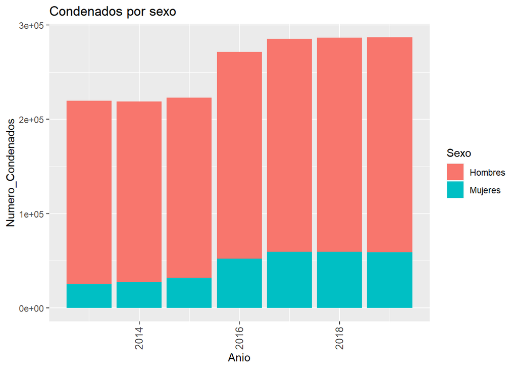

```r
datos_condenados_sexo <- subset(datos_condenados,subset=c(Comunidades == "Total" & Edad == "Total" & Sexo !="Total"))

ggplot(datos_condenados_sexo, aes(Anio, Numero_Condenados, fill = Sexo)) +
geom_bar(stat = "identity") +
ggtitle("Condenados por sexo") +
theme(axis.text.x = element_text(angle = 90, size = 10, vjust = 0.4),legend.position = "right")
```

Se analizan los condenados por edad

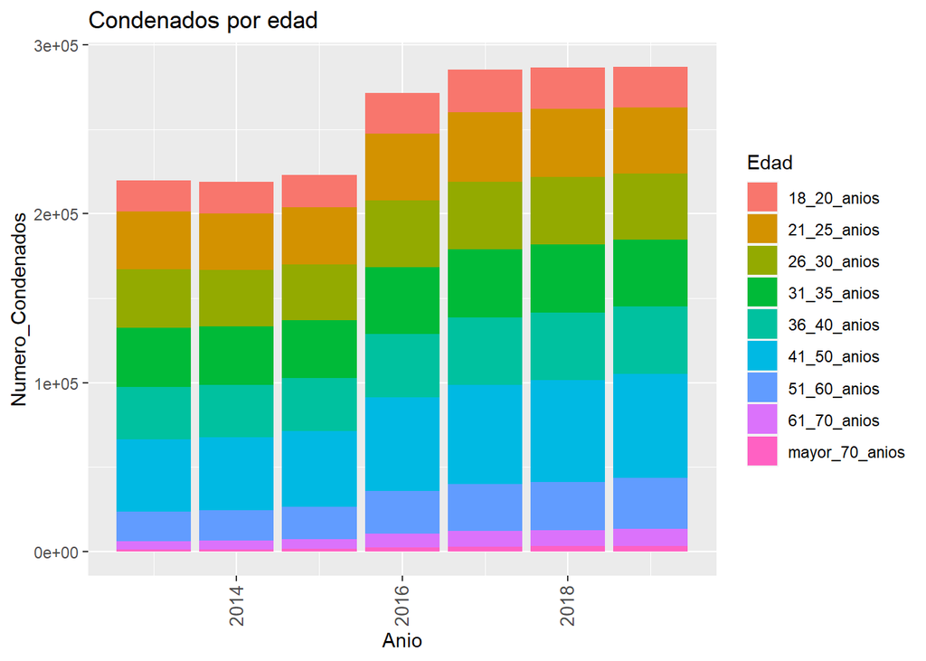

```r
datos_condenados_edad <- subset(datos_condenados,subset=c(Comunidades == "Total" & Sexo == "Total" & Edad !="Total"))

ggplot(datos_condenados_edad, aes(Anio, Numero_Condenados, fill = Edad)) +
geom_bar(stat = "identity") +
ggtitle("Condenados por edad") +
theme(axis.text.x = element_text(angle = 90, size = 10, vjust = 0.4),legend.position = "right")
```

Se analizan los condenados por comunidad autónoma

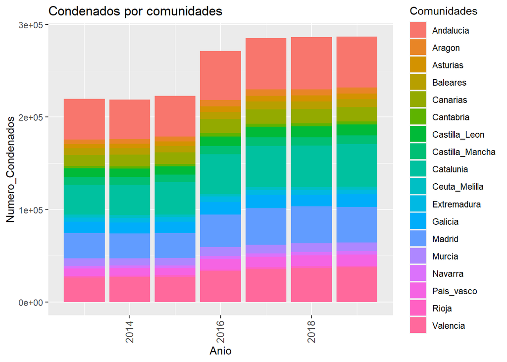

```r
datos_condenados_comunidades <- subset(datos_condenados,subset=c(Comunidades != "Total" & Sexo == "Total" & Edad =="Total"))

ggplot(datos_condenados_comunidades, aes(Anio, Numero_Condenados, fill = Comunidades)) +
geom_bar(stat = "identity") +
ggtitle("Condenados por comunidades") +
theme(axis.text.x = element_text(angle = 90, size = 10, vjust = 0.4),legend.position = "right")
```

Se analizan los condenados por sexo y edad

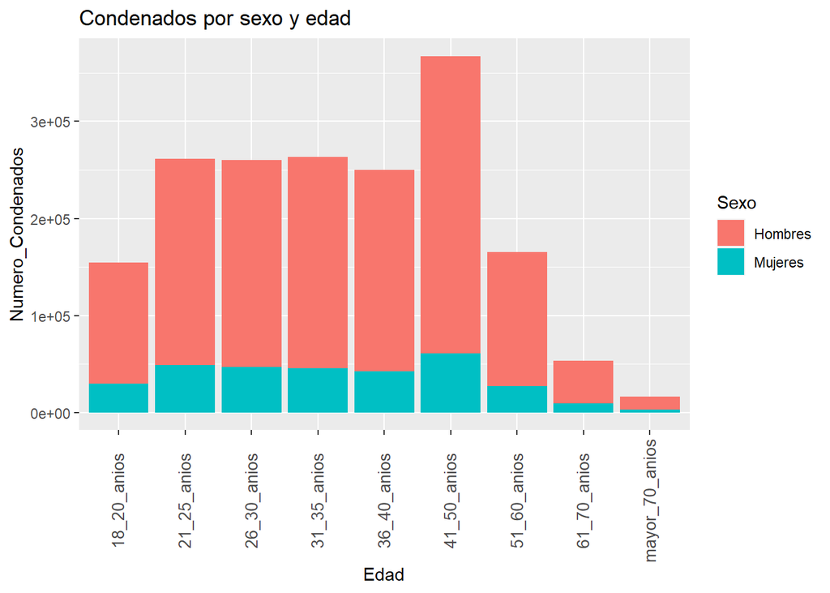

```r
datos_condenados_sexo_edad <- subset(datos_condenados,subset=c(Comunidades == "Total" & Sexo != "Total" & Edad !="Total"))

ggplot(datos_condenados_sexo_edad, aes(Edad, Numero_Condenados, fill = Sexo)) +
geom_bar(stat = "identity") +
ggtitle("Condenados por sexo y edad") +
theme(axis.text.x = element_text(angle = 90, size = 10, vjust = 0.4),legend.position = "right")
```

# 4 Formateo y tratamiento de los datos

Se formatean las columnas Comunidades, Edad y Sexo como factores

```r
datos_condenados <- datos_condenados[datos_condenados$Comunidades != "Total" & datos_condenados$Edad != "Total" & datos_condenados$Sexo != "Total", ]

factor.columns <- c("Comunidades","Edad","Sexo")
datos_condenados[factor.columns] <- lapply(datos_condenados[factor.columns], factor)
str(datos_condenados)
```

```
## 'data.frame':    2394 obs. of  5 variables:
##  $ Comunidades      : Factor w/ 18 levels "Andalucia","Aragon",..: 1 1 1 1 1 1 1 1 1 1 ...
##  $ Anio             : int  2019 2018 2017 2016 2015 2014 2013 2019 2018 2017 ...
##  $ Sexo             : Factor w/ 2 levels "Hombres","Mujeres": 1 1 1 1 1 1 1 1 1 1 ...
##  $ Edad             : Factor w/ 9 levels "18_20_anios",..: 1 1 1 1 1 1 1 2 2 2 ...
##  $ Numero_Condenados: int  3333 3610 3717 3761 3254 3263 3481 5557 6201 6183 ...
```

Se mira el porcentaje de nulos de cada una de las columnas

```r
#Se mira el porcentaje de nulos de cada una de las columnas y se analizan cada uno de ellos
apply(is.na(datos_condenados),2,sum) / nrow(datos_condenados)*100
```

```
##       Comunidades              Anio              Sexo              Edad
##                 0                 0                 0                 0
## Numero_Condenados
##                 0
```

Se convierten los datos categóricos en variables dummies para que todas las variables estén representadas por un valor numérico.

```r
datos_condenados_dummies <- dummy.data.frame(datos_condenados,dummy.class="factor")
datos_condenados_dummies
```

[output not shown]

[output cut: 21540 more lines]

Se van analizar los distintos perfiles a lo largo de los años, con lo cual se coge como muestra sólo los datos del año 2013

```r
#Como muestra solo se escoge el año  para el 2013
datos_condenados_dummies_2013 <- subset(datos_condenados_dummies,subset=c(Anio == 2013))

datos_condenados_dummies_2013
```

[output not shown]

[output cut: 3072 more lines]

```r
#No necesitamos la variable año
datos_condenados_dummies_2013$Anio=NULL
```

# 5 Clustering

Se analizan el número de clústers necesarios para identificar los distintos perfiles

## 5.1 Análisis del número de clústers

### 5.1.1 KMEANS

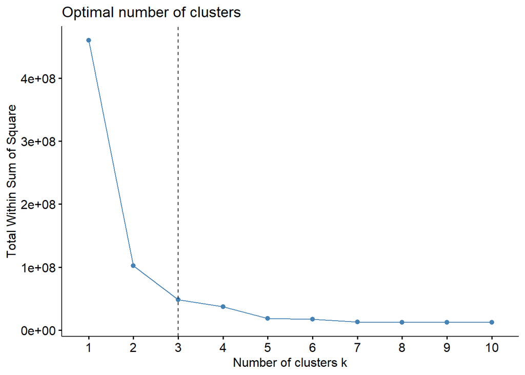

```r
#Metodo del codo KMEANS
fviz_nbclust(datos_condenados_dummies_2013, kmeans, method = "wss") + geom_vline(xintercept = 3, linetype = 2)
```

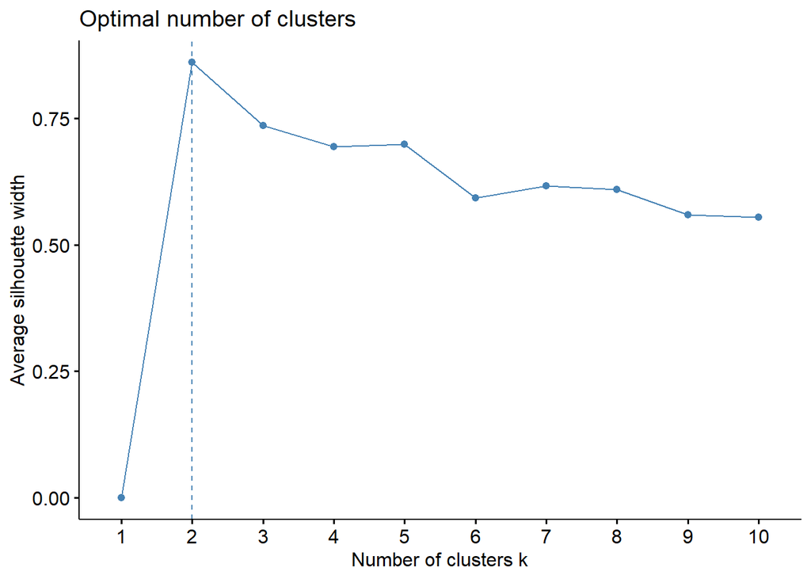

```r
#Metodo de la silhouette KMEANS
fviz_nbclust(datos_condenados_dummies_2013, kmeans, method = "silhouette")
```

### KMEDOIDS

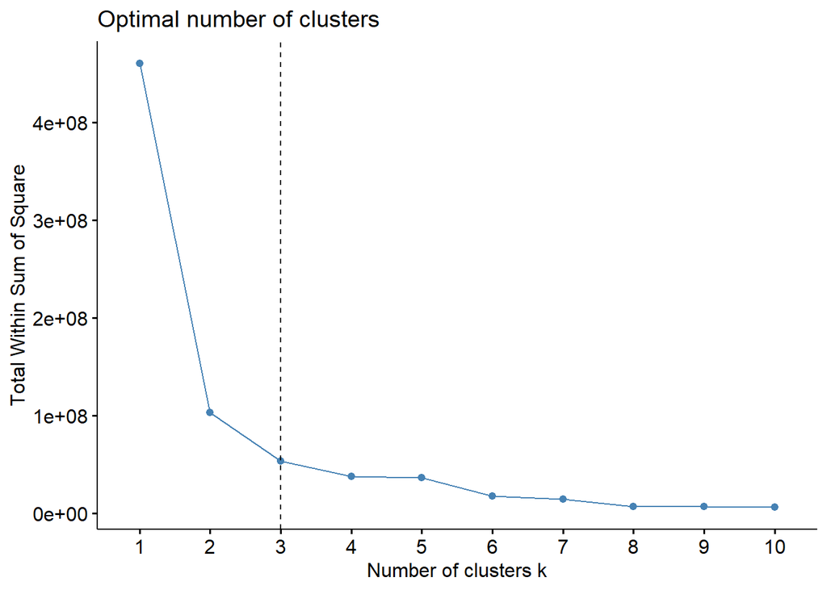

```r
#Metodo del codo KMEDOIDS
fviz_nbclust(datos_condenados_dummies_2013, pam, method = "wss") + geom_vline(xintercept = 3, linetype = 2)
```

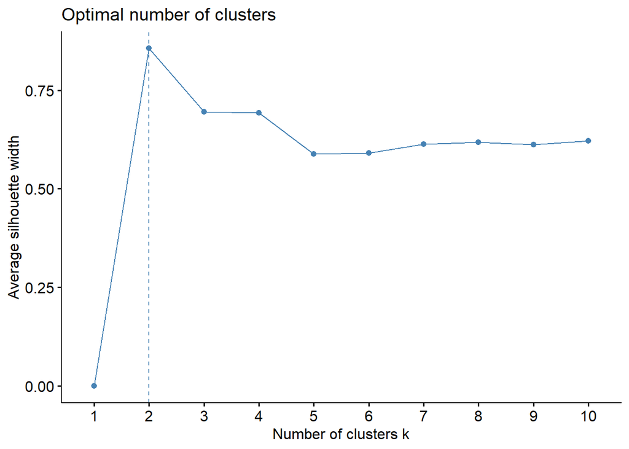

```r
#Metodo de la silhouette KMEDOIDS
fviz_nbclust(datos_condenados_dummies_2013, pam, method = "silhouette")
```

### 5.1.2 HCLUST

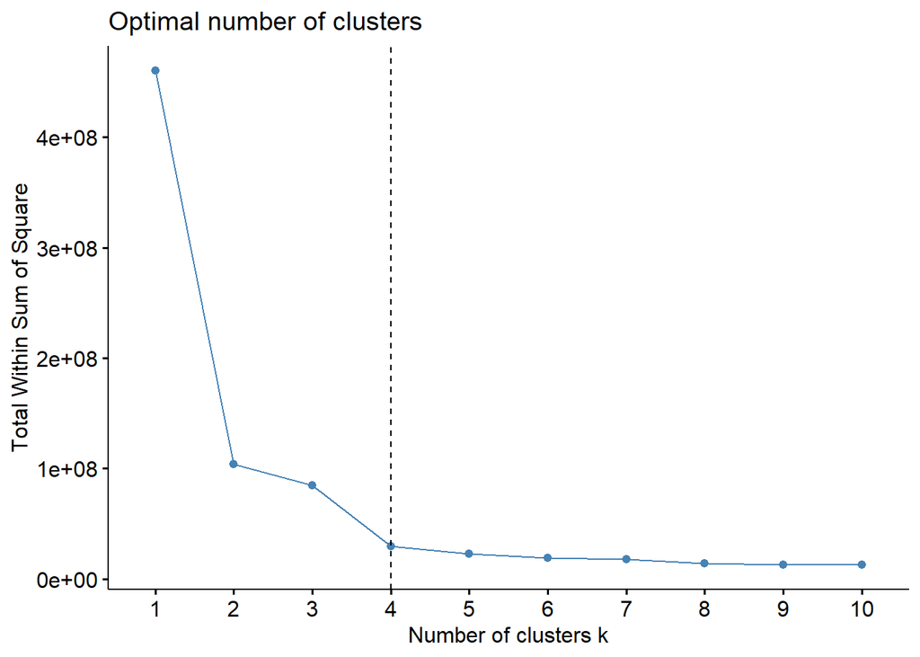

```r
#Metodo del codo HCLUST
fviz_nbclust(datos_condenados_dummies_2013, hcut, method = "wss",k.max=10, hc_method = "complete")  + geom_vline(xintercept = 4, linetype = 2)
```

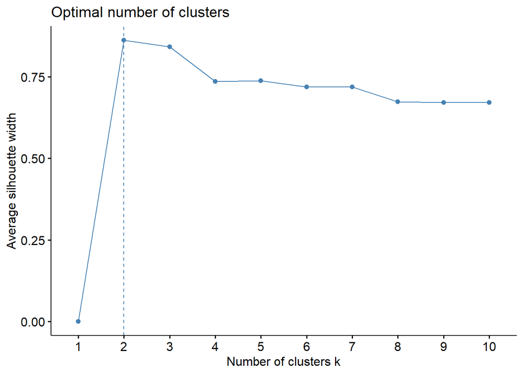

```r
#Metodo de la silhouette HCLUST
fviz_nbclust(datos_condenados_dummies_2013, hcut, method = "silhouette",k.max=10, hc_method = "complete")
```

Dado que el método del codo no se aprecia bien el número de clusters seleccionados, se escoge el método de la silhouette para determinar los clusters. En este caso, para los 3 modelos, el número de clusters son 2.

```r
#Se definen el número de clusters
NUM_CLUSTERS=2
set.seed(1200)
```

## 5.2 Normalización

Se normalizan los datos para que todas las variables tengan el mismo peso en el análisis

```r
#Se normalizan los datos
datos_condenados_dummies_2013_nor=scale(datos_condenados_dummies_2013)
```

## 5.3 Creación de modelos

Se crean los 3 modelos de clúster y se guarda el grupo de la segmentación al que pertenece cada registro en las distintas columnas del dataset datos_condenados_dummies_2013 (Segmentos_kmeans, Segmentos_kmdeoids, Segmentos_hclust)

Se muestra el deograma generado por el modelo de HClust

### 5.3.1 KMEANS

```r
#KMEANS
Modelo_kmeans=kmeans(datos_condenados_dummies_2013_nor,NUM_CLUSTERS)
datos_condenados_dummies_2013$Segmentos_kmeans=Modelo_kmeans$cluster
```

### 5.3.2 KMEDOIDS

```r
#KMEDOIDS
Modelo_kmedoids=pam(datos_condenados_dummies_2013_nor,NUM_CLUSTERS, metric = "euclidean")
datos_condenados_dummies_2013$Segmentos_kmdeoids=Modelo_kmedoids$cluster
```

### 5.3.3 HCLUST

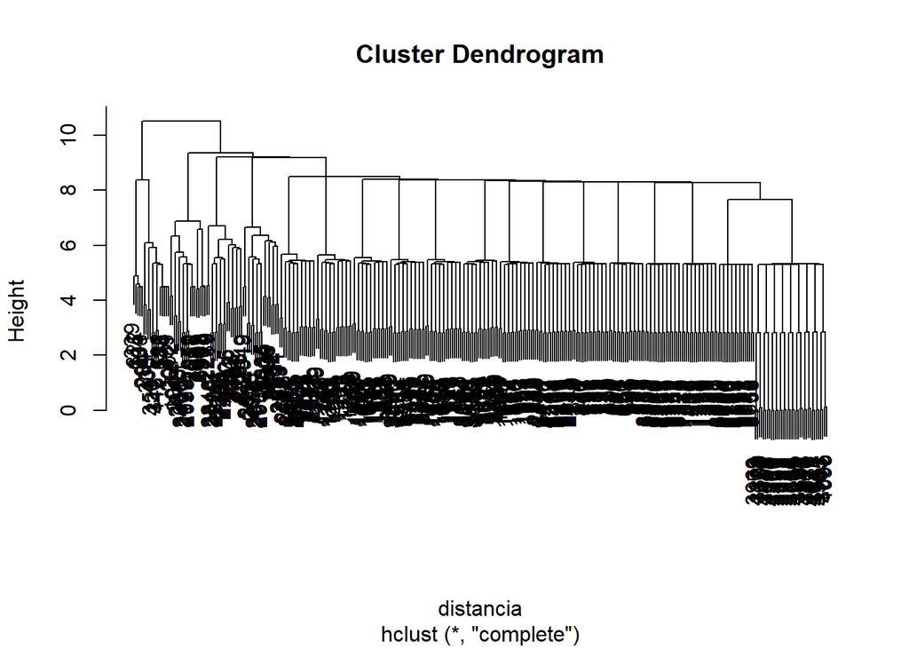

```r
#HCLUST
distancia <- dist(datos_condenados_dummies_2013_nor, method = "euclidean")
Modelo_hclust<- hclust(distancia, method = "complete")
datos_condenados_dummies_2013$Segmentos_hclust = cutree(Modelo_hclust, k = NUM_CLUSTERS)
plot(Modelo_hclust)
```

```r
head(datos_condenados_dummies_2013)
```

```
##     ComunidadesAndalucia ComunidadesAragon ComunidadesAsturias
## 294                    1                 0                   0
## 301                    1                 0                   0
## 308                    1                 0                   0
## 315                    1                 0                   0
## 322                    1                 0                   0
## 329                    1                 0                   0
##     ComunidadesBaleares ComunidadesCanarias ComunidadesCantabria
## 294                   0                   0                    0
## 301                   0                   0                    0
## 308                   0                   0                    0
## 315                   0                   0                    0
## 322                   0                   0                    0
## 329                   0                   0                    0
##     ComunidadesCastilla_Leon ComunidadesCastilla_Mancha ComunidadesCatalunia
```

[output cut: 55 more lines]

### 5.3.4 Tamaños de los clústers

Se obtienen los tamaños de cada cluster para cada uno de los 3 modelos.

```r
#Tamaños de los clusters
table(datos_condenados_dummies_2013$Segmentos_kmeans)
```

```
##
##   1   2
## 171 171
```

```r
table(datos_condenados_dummies_2013$Segmentos_kmdeoids)
```

```
##
##   1   2
## 171 171
```

```r
table(datos_condenados_dummies_2013$Segmentos_hclust)
```

```
##
##   1   2
##  18 324
```